# Bakery Sales

###Calculating the Frequency of the Period Day The data is counting the frequency of the time it was purchased such as night, evening, afternoon, and morning. The results were stored in a new table called daypart_counts for further visualization and analysis.

```r
daypart_counts <- Bakery %>%
  count(period_day, sort = TRUE)
```

###Period Day Frequency Bar Graph Period day frequency was analyzed to identify the bakery’s highest and lowest time of selling the products using a bargraph, providing insight into the time customer mostly come in to buy something from the bakery.

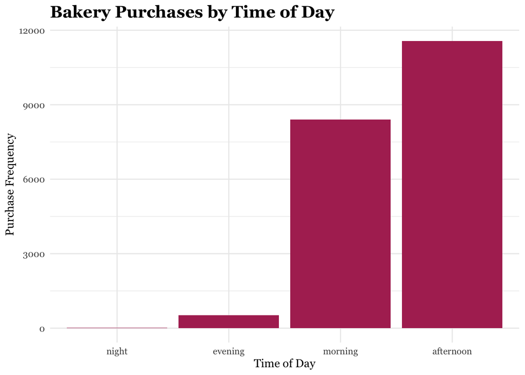

```r
ggplot(daypart_counts, aes(x = reorder(period_day, n), y = n)) +
  geom_bar(stat = "identity", fill = "maroon") +
  labs(
    title = "Bakery Purchases by Time of Day",
    x = "Time of Day",
    y = "Purchase Frequency"
  ) +
  theme_minimal() +
  theme(
    text = element_text(family = "Georgia"),
    plot.title = element_text(face = "bold", size = 16)
  )
```

####Result The bar graph shows that the bakery is mostly active in selling goods in the afternoon, then morning would be the most second active time. The evening and night showcases a dramatic difference in purchase brought, with barley activity of items being purchased during those times.

###Calculating the Frequency of Items Bought on either a Weekend or Weekday The data is counting the frequency of the weither an item was bought on a weekend or weekday. The results were stored in a new table called behavior_counts for further visualization and analysis.

```r
behavior_counts <- Bakery %>%
  count(weekday_weekend, sort = TRUE)
```

###Weekend vs Weekday Frequency Bar Graph The weekday_weekend was analyzed to identify the bakery’s highest and lowest time of selling the products between weekday vs weekwend using a bargraph, providing insight into the days customer mostly come in to buy something from the bakery.

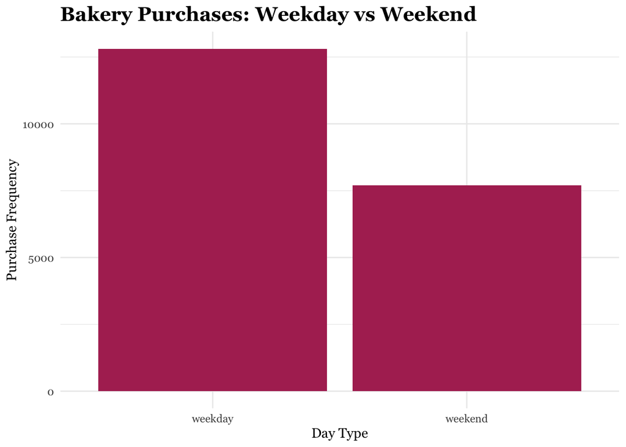

```r
ggplot(behavior_counts, aes(x = weekday_weekend, y = n)) +
  geom_bar(stat = "identity", fill = "maroon") +
  labs(
    title = "Bakery Purchases: Weekday vs Weekend",
    x = "Day Type",
    y = "Purchase Frequency"
  ) +
  theme_minimal() +
  theme(
    text = element_text(family = "Georgia"),
    plot.title = element_text(face = "bold", size = 16)
  )
```

####Result The bar graph shows that most of the bakery purchases are bought mostly on the weekdays compared to the weekend.

###Calculating the Frequency of Items Bought on either a Weekend or Weekday The data is counting the frequency in which products (the top 10) were mostly bought on a weekday and weekend.The results were stored in a new table called top_items_daytype.

```r
top_items_daytype <- Bakery %>%
  count(weekday_weekend, Item, sort = TRUE) %>%
  group_by(weekday_weekend) %>%
  slice_max(order_by = n, n = 10)
```

###Frequency of Items Bought on either a Weekend or Weekday Bar Graph The weekday_weekend was analyzed to identify the bakery’s highest products sold between weekend and weekday.

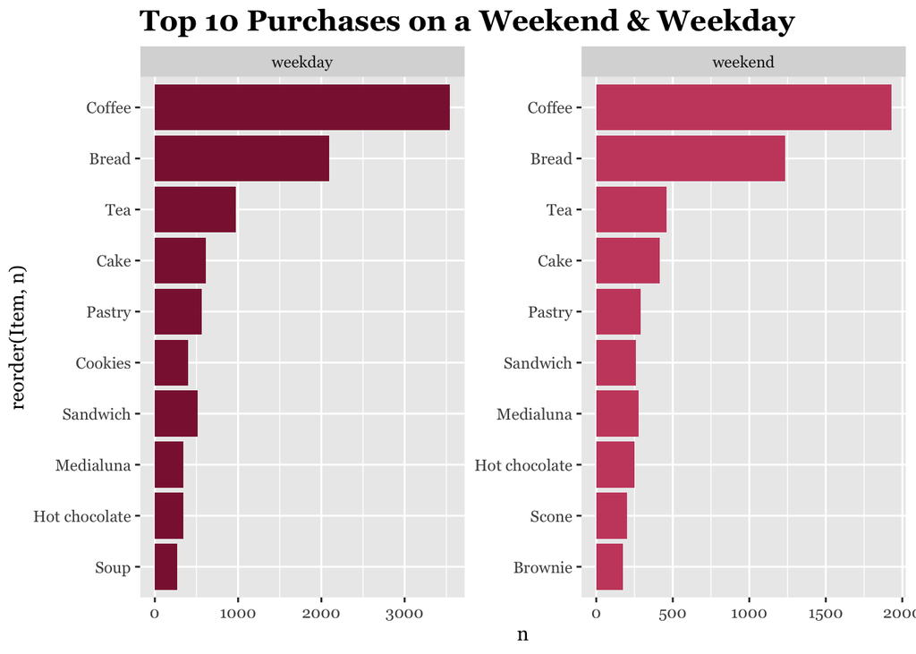

```r
ggplot(top_items_daytype, aes(x = reorder(Item, n), y = n, fill = weekday_weekend)) +
  geom_bar(stat = "identity") +
  coord_flip() +
  facet_wrap(~weekday_weekend, scales = "free") +
  scale_fill_manual(values = c(
    "weekday" = "#8B1E3F",
    "weekend" = "#C94C6D"
  )) +
  labs(
    title = "Top 10 Purchases on a Weekend & Weekday"
  ) +
  theme(
    legend.position = "none",
    text = element_text(family = "Georgia"),
    plot.title = element_text(face = "bold", size = 16)
  )
```

###Calculating the Frequency of Items Bought in each Time Period of the Day The data is counting the frequency of how many products, are being sold at specific time period of the day (afternoon, evening, night, and morning). The results were stored in a new table called top_items_time.

```r
top_items_time <- Bakery %>%
  count(period_day, Item, sort = TRUE) %>%
  group_by(period_day) %>%
  slice_max(order_by = n, n = 5)
```

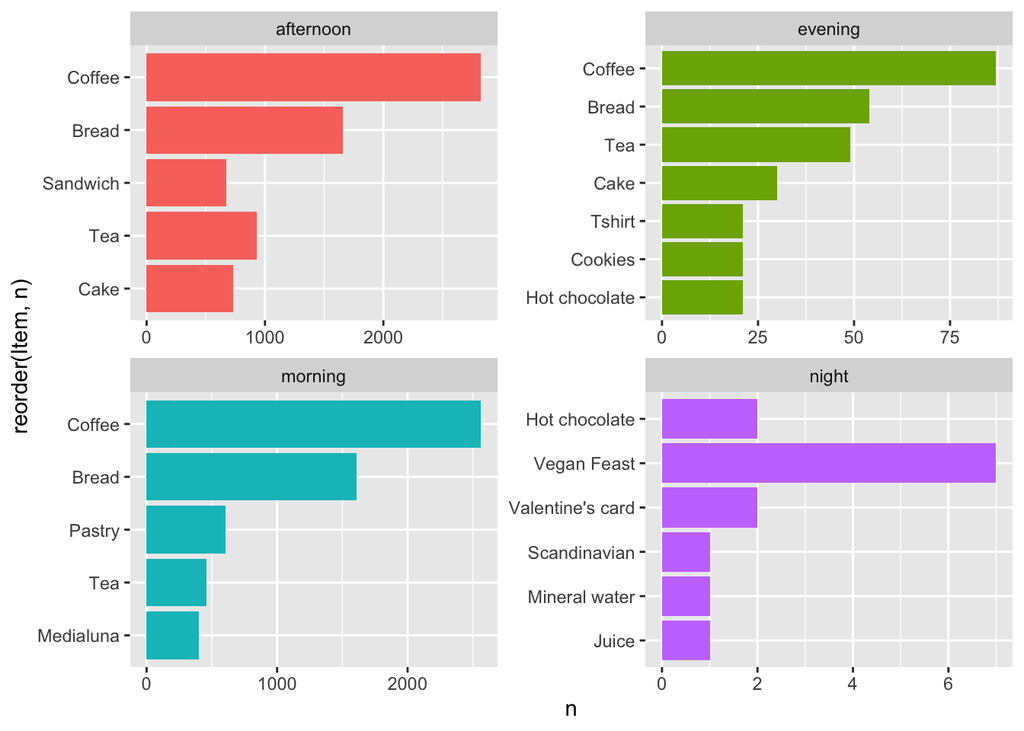

```r
ggplot(top_items_time, aes(x = reorder(Item, n), y = n, fill = period_day)) +
  geom_bar(stat = "identity") +
  coord_flip() +
  facet_wrap(~period_day, scales = "free") +
  theme(legend.position = "none")
```

###Reconstructing Dataset This code restructures the dataset into a transaction-based format by grouping items purchased together within each transaction, allowing the Apriori algorithm to analyze product combinations.

```r
transactions <- split(Bakery$Item, Bakery$Transaction)
transactions <- as(transactions, "transactions")
```

###Running Apriori This code runs the Apriori algorithm to identify product combinations that frequently occur together in customer transactions, based on minimum support and confidence thresholds.

```r
rules <- apriori(transactions,
                 parameter = list(
                   supp = 0.01,
                   conf = 0.3,
                   target = "rules"
                 ))
```

```
## Apriori
##
## Parameter specification:
##  confidence minval smax arem  aval originalSupport maxtime support minlen
##         0.3    0.1    1 none FALSE            TRUE       5    0.01      1
##  maxlen target  ext
##      10  rules TRUE
##
## Algorithmic control:
##  filter tree heap memopt load sort verbose
##     0.1 TRUE TRUE  FALSE TRUE    2    TRUE
##
## Absolute minimum support count: 94
##
## set item appearances ...[0 item(s)] done [0.00s].
## set transactions ...[94 item(s), 9465 transaction(s)] done [0.00s].
## sorting and recoding items ... [30 item(s)] done [0.00s].
## creating transaction tree ... done [0.00s].
## checking subsets of size 1 2 3 done [0.00s].
## writing ... [21 rule(s)] done [0.00s].
## creating S4 object  ... done [0.00s].
```

###Ranking Apriori This code ranks association rules by lift and selects the strongest product relationships for analysis.

```r
inspect(sort(rules, by = "lift")[1:10])
```

```
##      lhs                 rhs      support    confidence coverage   lift
## [1]  {Toast}          => {Coffee} 0.02366614 0.7044025  0.03359746 1.472431
## [2]  {Spanish Brunch} => {Coffee} 0.01088220 0.5988372  0.01817221 1.251766
## [3]  {Medialuna}      => {Coffee} 0.03518225 0.5692308  0.06180666 1.189878
## [4]  {Pastry}         => {Coffee} 0.04754358 0.5521472  0.08610671 1.154168
## [5]  {Alfajores}      => {Coffee} 0.01965135 0.5406977  0.03634443 1.130235
## [6]  {Juice}          => {Coffee} 0.02060222 0.5342466  0.03856313 1.116750
## [7]  {Sandwich}       => {Coffee} 0.03824617 0.5323529  0.07184363 1.112792
## [8]  {Cake}           => {Coffee} 0.05472795 0.5269583  0.10385631 1.101515
## [9]  {Scone}          => {Coffee} 0.01806656 0.5229358  0.03454834 1.093107
## [10] {Cookies}        => {Coffee} 0.02820919 0.5184466  0.05441099 1.083723
##      count
## [1]  224
## [2]  103
## [3]  333
## [4]  450
## [5]  186
## [6]  195
## [7]  362
## [8]  518
## [9]  171
## [10] 267
```

```r
top_rules <- inspect(sort(rules, by = "lift")[1:5])
```

```
##     lhs                 rhs      support    confidence coverage   lift
## [1] {Toast}          => {Coffee} 0.02366614 0.7044025  0.03359746 1.472431
## [2] {Spanish Brunch} => {Coffee} 0.01088220 0.5988372  0.01817221 1.251766
## [3] {Medialuna}      => {Coffee} 0.03518225 0.5692308  0.06180666 1.189878
## [4] {Pastry}         => {Coffee} 0.04754358 0.5521472  0.08610671 1.154168
## [5] {Alfajores}      => {Coffee} 0.01965135 0.5406977  0.03634443 1.130235
##     count
## [1] 224
## [2] 103
## [3] 333
## [4] 450
## [5] 186
```

```r
inspect(sort(rules, by = "lift"))
```

```
##      lhs                 rhs      support    confidence coverage   lift
## [1]  {Toast}          => {Coffee} 0.02366614 0.7044025  0.03359746 1.4724315
## [2]  {Spanish Brunch} => {Coffee} 0.01088220 0.5988372  0.01817221 1.2517655
## [3]  {Medialuna}      => {Coffee} 0.03518225 0.5692308  0.06180666 1.1898784
## [4]  {Pastry}         => {Coffee} 0.04754358 0.5521472  0.08610671 1.1541682
## [5]  {Alfajores}      => {Coffee} 0.01965135 0.5406977  0.03634443 1.1302349
## [6]  {Juice}          => {Coffee} 0.02060222 0.5342466  0.03856313 1.1167500
## [7]  {Sandwich}       => {Coffee} 0.03824617 0.5323529  0.07184363 1.1127916
## [8]  {Cake}           => {Coffee} 0.05472795 0.5269583  0.10385631 1.1015151
## [9]  {Scone}          => {Coffee} 0.01806656 0.5229358  0.03454834 1.0931067
## [10] {Cookies}        => {Coffee} 0.02820919 0.5184466  0.05441099 1.0837229
## [11] {Hot chocolate}  => {Coffee} 0.02958267 0.5072464  0.05832013 1.0603107
## [12] {Pastry}         => {Bread}  0.02916006 0.3386503  0.08610671 1.0349774
## [13] {Brownie}        => {Coffee} 0.01965135 0.4907652  0.04004226 1.0258596
## [14] {Muffin}         => {Coffee} 0.01880613 0.4890110  0.03845747 1.0221928
```

[output cut: 29 more lines]

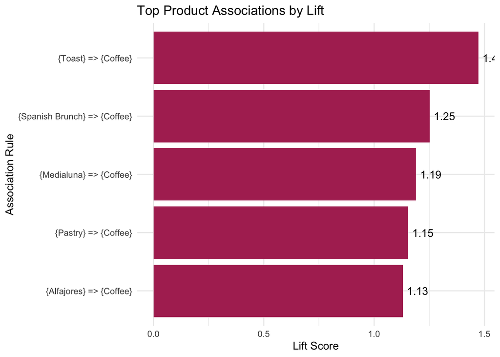

```r
top_rules_df <- as(sort(rules, by = "lift"), "data.frame")[1:5,]

ggplot(top_rules_df, aes(x = reorder(rules, lift), y = lift)) +
  geom_bar(stat = "identity", fill = "maroon") +
  coord_flip() +
  geom_text(aes(label = round(lift, 2)), hjust = -0.2) +
  labs(
    title = "Top Product Associations by Lift",
    x = "Association Rule",
    y = "Lift Score"
  ) +
  theme_minimal()
```

Based on these findings, several strategic recommendations can be made. The bakery should consider implementing bundled promotions, such as coffee paired with toast or pastries, to increase average transaction value. Optimizing store layout by placing coffee near high-demand complementary items could further encourage cross-selling behavior. Additionally, targeted marketing campaigns focusing on breakfast combinations may enhance customer engagement during peak periods. Finally, leveraging these associations in digital or in-store recommendations can help guide customer purchasing decisions and improve overall sales performance.

This analysis explored bakery transaction data to better understand customer purchasing behavior and product relationships. The results showed that demand is heavily concentrated around staple items such as coffee and bread, with strong associations between coffee and breakfast-related products. These findings highlight the importance of complementary purchasing behavior and demonstrate how data-driven insights can be used to improve product strategy, increase sales, and enhance the overall customer experience.

While this analysis provides valuable insights, it is limited by the absence of pricing and customer demographic data, restricting the ability to assess profitability and segment customer behavior. Additionally, the dataset represents a single bakery location, which may limit the generalizability of the findings.